# ImageNet (huge dataset, millions of images)

> task: classify images correctly (dog, car, etc.)  
> CNNs are used for this.

# AlexNet

AlexNet is the first model < 25% error on ImageNet

> It's just a big CNN that takes an image and outputs a class

### Structure:

→ Conv  
→ Conv  
→ Conv  
→ Conv  
→ Conv (5 convolutional layers)

→ Fully Connected  
→ Fully Connected  
→ Fully Connected (3 FC layers)

With:

- ReLU
- MaxPooling

> STEP 1 — Input

> STEP 2 — First convolution
- Small filters slide over the image
- Each filter = pattern detector

Example filters:

- edge detector
- color detector
- gradient detector

So output: many feature maps (channels)

> STEP 3 — ReLU
- ReLU(x) = max(0, x)
  - remove negative values
  - introduce non-linearity

> MaxPooling
- Take a window (e.g. 2×2):

[1 5]  
[2 3]  
→ keep 5

↓ reduce size  
↓ keep strongest signals

> Repeat

# What changes as we go deeper?

- Early layers: edges, colors
- Middle layers: textures, shapes
- Deep layers: object parts (eye, wheel, face)

> After conv layers: you **flatten** everything:
- (256, H, W) → huge vector

Then pass it through 3 fully connected layers: → Fully Connected  
→ Fully Connected  
→ Fully Connected

# This is the big problem

> “AlexNet produced a lot of parameters”

Consequence:  
→ slow training  
→ huge memory  
→ needed 2 GPUs (crazy for 2012)

### Why AlexNet has problems

- Too many parameters

Because of fully connected layers

- Slow

Even for today FC layers = inefficient

- **Hard to scale deeper**

> **deeper networks → worse performance**  
> **wtf? more layers = more power, so it should be better, why worse?**

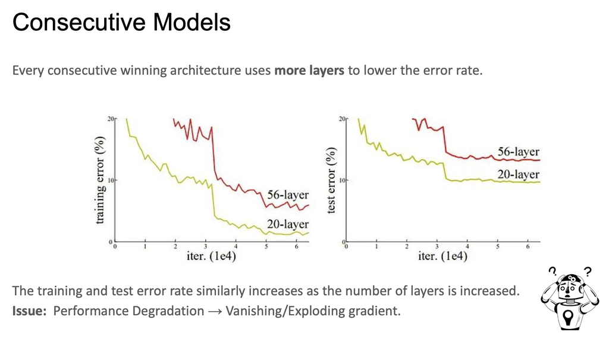

**vanishing / exploding gradients ... what do you mean?**

More layers stacked:  
input → L1 → L2 → L3 → ... → L50 → output

In training we do:  
forward pass → compute loss → **backpropagation**

Error is computed at the END:  
output → loss

Then propagated BACK:  
L50 ← L49 ← ... ← L1

> This is backpropagation.

More formally, when performing backpropagation we need to compute the gradient of loss w.r.t. weights of EACH layer --> Backprop uses chain rule so:  
$\frac{\partial L}{\partial W^1} = \frac{\partial L}{\partial z^{50}} \cdot \frac{\partial z^{50}}{\partial z^{49}} \cdot \frac{\partial z^{49}}{\partial z^{48}} \cdots \frac{\partial z^{2}}{\partial z^{1}} \cdot \frac{\partial z^{1}}{\partial W^1}$

- So the gradient gets multiplied MANY times, by:

###### (derivatives of activation functions (e.g. sigmoid, tanh)) --> ignore

  - **weights of the network, weights of each layer**
- Gradients involve: multiplications by the weight of each layer W^l (or its transpose)
  - weights can be:
    - < 1 → shrink gradient
    - 1 → blow up gradient

### IF weights have magnitude < 1:

Then: gradient ≈ small × small × small × ... × small → goes to 0

Consequence:  
Early layers (close to input):  
→ receive almost zero gradient  
→ weights do NOT update  
→ they do NOT learn

### If weights have magnitude > 1

Then: gradient ≈ large × large × large × ... × large → becomes huge

Consequence:  
→ unstable updates  
→ weights jump randomly  
→ loss explodes  
→ training diverges

## Conclusion:

The gradient is repeatedly multiplied by:

###### - activation derivatives

- **weights**

> If these are <1 → vanishing  
> If >1 → exploding

So deeper networks are harder to train because gradients either:

- disappear
- or explode

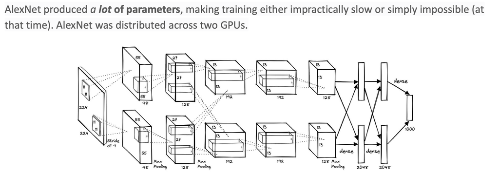

# Can't we fix unstable gradients with Batch Normalisation?

We said: deep network → gradient = product of many terms → can vanish or explode  
BN does: $\hat{x} = \frac{x - \mu}{\sigma}$

So forcing:

- mean ≈ 0
- variance ≈ 1

BN = stabilizes distributions → stabilizes gradients

So, BN helps because:

- prevents activations from becoming huge
- reduces gradient explosion
- makes training more stable
- allows higher learning rates

# BUT

BN does NOT solve the problem of chain of multiplications: it does not remove the chain of multiplications, so:

- Deep multiplication problem still exists
  - Even if each term ≈ 0.9 --> 0.9 × 0.9 × 0.9 × ... (50 times) → small

# So ... what's the solution? How do we make deep networks trainable?

# **ResNet**

> ResNet IS A CNN THAT USES **RESIDUAL BLOCKS** --> residual blocks are the solution of the exploding / vanishing gradient

# What is a residual block?

> Each layer adds something to the previous value

Instead of: $y = H(x)$  
We do: $y = F(x) + x$

- x = input to ONE residual block
- F(x) = output of the conv layers inside the block
- y = output of the residual block

> Let's make this clearer:
- x = input to ONE residual block

Example: After some conv layers, you might have:  
$x \in \mathbb{R}^{(batch, channels, height, width)}$

Concrete example:  
$x \in \mathbb{R}^{(32, 64, 56, 56)}$

- 32 images
- 64 feature maps
- 56×56 resolution
- F(x) = output of the conv layers inside the residual block

Example: x → conv → relu → conv → F(x)

> Example
- The workflow of the NN is: Input image → conv layers → produces x
- each input image: (3, 224, 224) --> RGB image with 224x224 resolution
- we consider batches of 64 images --> (64, 3, 224, 224) --> 64 images, each is an RGB image with resolution 224x224
- consider only one image: x[0, :, :, :] = feature maps of image 1 --> (1, 3, 224, 224)

###### - it should actually be (3, 224, 224), it's just to get the idea

- we said the layers in the forward pass are: Input image → conv layers → produces x = **ALL THIS IS INSIDE A RESIDUAL BLOCK**
  - **IMPORTANT NOTE**: a residual block is NOT the entire network, it is just a SMALL PART (few layers) --> we are only considering the residual block but imagine that it is connected to other layers too, like more convoulational layers or fully connected layers, pooling, ecc.

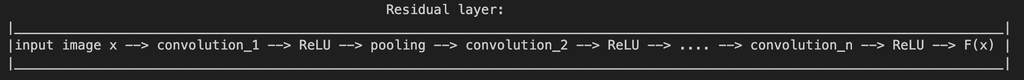

- So inside the residual block (considering only 1 image, batch of 1 image):
  - F(x) = conv(x) --> can this be considered the output of all the layers inside the residual block? **YES**
    - NOTE: F(x) will be the transformed initial image, it won't be a RGB image (3 channels), but it will have as many channels as the number of filters used in each convolutional layers and the resolution won't be 224x224 --> changed by the convoulational layers + pooling, so in this residual block:
      - input $x \in \mathbb{R}^{(1, 3, 224, 224)}$
      - output $F(x) \in \mathbb{R}^{(1, 64, 56, 56)}$
      - **INPUT WHICH MUST BE TRANSFORMED INTO THE SAME DIMENSION AS F(X): $\hat{x} \in \mathbb{R}^{(1, 64, 56, 56)}$**
        - Why? So we can perform element-wise addition: F(x) + x
        - **ARE WE FORCING F(X) TO HAVE THE SAME DIMENSION AS X OR VICE VERSA????**
        - 2 options:
          - Case A — “natural matching” (weird) - Goal $x \in (C, H, W) \quad \Rightarrow \quad F(x) \in (C, H, W)$

            > How?

            - Spatial size (H, W) --> use conv layers that preserve shape: kernel = 3, stride = 1, padding = 1  
            - Channels --> in_channels = out_channels

            - Example: $x \in (64, 56, 56)$ - Inside the residual block: - conv(64 → 64, stride=1) - conv(64 → 64, stride=1) - So output: $F(x) \in (64, 56, 56)$ --> F(x) + x works directly
          - Case B - forcing dimension matching - We want to sum: $x \in (64, 56, 56) \quad \rightarrow \quad F(x) \in (128, 28, 28)$ - But it's impossible if we don't change dimensions ... but of X or F(X)??? - **WE TRANSFORM X, NOT F(X)** - To force X to have the same shape as F(X) we can use convolutional layers or other approaches
  - F(x) = output of the layers in the residual blocks --> $F(x) \in \mathbb{R}^{(1, 64, 56, 56)}$
  - x = input of the residual block (transformed for dimension reasons) --> $\hat{x} \in \mathbb{R}^{(1, 64, 56, 56)}$
  - y = F(x) + x

> So take the transformed image (convoulational + ReLU + pooling layers) and sums to it the original image:
- $F(x) \in \mathbb{R}^{(1, **64, 56, 56**)}$

**+**

- $x \in \mathbb{R}^{(1, **64, 56, 56**)}$

The sum is perfomed element-wise = pixel-wise (56, 56) + (56, 56) and channel-wise (64) + (64)

# WHY THE FUCK ARE WE DOING THIS? WHAT SENSE DOES THIS MAKE?

> Trust the process --> compute the gradient of the loss function and look why it makes sense:

We said: x --> residual block with inside: (convoulational + ReLU + pooling layers → F(x)) --> y = F(x) + x → loss  
We need to compute the loss gradient --> partial derivative of the loss with respect to the weights: $\frac{\partial L}{\partial W}$

**BUT:** To compute gradients wrt weights, gradients must FLOW THROUGH x --> explain better:

- Hypothesize a layer like this:

$$y = W x$$

- we compute the Loss, which depend on the output of that layer:

$L = L(y)$

- we want to minimize the loss --> compute gradient and update the new wights in the opposite direction fo the gradient:
- so compute gradient of the loss = partial derivative of the loss with respect to the weights:

$\frac{\partial L}{\partial W}$

- we know: y = W x --> L(y)

###### L depends on y

- we want $\frac{\partial L}{\partial W}$
- so we have to go backwards: go from here L(y) to here y = W x
- so due to the chain rule: $\frac{\partial L}{\partial W} = \frac{\partial L}{\partial y} \cdot \frac{\partial y}{\partial W}$

> **BUT**
- we said: $y = W x$
- So: $\frac{\partial y}{\partial W} \propto x$
> - **Gradient wrt W depends on x**

> To update W, you need x

> Ok so we said we need: $\frac{\partial L}{\partial x} = \frac{\partial L}{\partial y} \cdot \frac{\partial y}{\partial x}$
- but we previously said and did: $y = F(x) + x$
- so if we actually do the partial derivative:

$\frac{\partial y}{\partial x}=\frac{\partial F(x)}{\partial x}+1$

__

**IN THE END WE OBTAIN:**  
GRADIENT LOSS = $\frac{\partial L}{\partial x} = \frac{\partial L}{\partial y} \cdot \frac{\partial y}{\partial x} = \frac{\partial L}{\partial y} \cdot \frac{\partial F(x)}{\partial x}+1$

__

# THIS IS THE WHOLE POINT

> Without residual: y = F(x)

$\frac{\partial y}{\partial x} = \frac{\partial F}{\partial x}$  
→ gradient gets multiplied many times → vanishes

> With residual:

$\frac{\partial y}{\partial x} = \frac{\partial F}{\partial x} + 1$

As a consequence:

- Even if: $\frac{\partial L}{\partial x} ≈ 0$
- You still have:+1 → gradient survives

# Are we sure this + x --> + 1 for the gradient solves our gradient size problem?

#### Original gradient problem

- In a deep network:

$x \rightarrow L1 \rightarrow L2 \rightarrow \dots \rightarrow L50 \rightarrow L$

- Backprop:

$ \frac{\partial L}{\partial x} = \frac{\partial L}{\partial z^{50}} \cdot \frac{\partial z^{50}}{\partial z^{49}} \cdot \frac{\partial z^{49}}{\partial z^{48}} \cdots \frac{\partial z^2}{\partial z^1} \cdot \frac{\partial z^1}{\partial x}$

- gradient ≈ W1 × W2 × W3 × ... × W50 --> is the product of many things
- If each term ≈ 0.9 → $0.9^{50} \approx 0$
- if each term ≈ 1.1 → $1.1^{50} \approx huge$

> So the conclusion: deep chain of multiplications = unstable gradients

#### What a residual block does

> Without residual: x → F1 → F2 → F3 → F4 → ...
- Gradient: gradient ≈ W1 × W2 × W3 × ... × W50 --> is the product of many things --> **pure multiplication chain**

> With residual blocks
- Each block: y = F(x) + x
- We know $\frac{\partial L}{\partial W} = \frac{\partial L}{\partial y} \cdot \frac{\partial y}{\partial W}$
- And we know: $\frac{\partial y}{\partial x} = \frac{\partial F}{\partial x} + 1$
- So the gradient becomes: $\frac{\partial L}{\partial W} = \frac{\partial L}{\partial y} \cdot \frac{\partial y}{\partial W}$ --> $\frac{\partial L}{\partial x} = \frac{\partial L}{\partial y} \cdot \prod_{layers} \left( \frac{\partial F}{\partial x} + 1 \right)$

# DOUBT: Is this actually helping the gradient not to vanish / explode?

*“I only added a +1 --> small number + 1 ≈ small number --> (small number + 1) x (small number + 1) x ... = (small number + 1)^50 ≈ (small_number)^50 ≈ 0 --> still vanishes”*

- You think there is ONE gradient path
- When in reality now there are MULTIPLE paths and they SUM

> What the fuck does this Shifu bullshit mean?

**EXAMPLE**  
Take 2 residual blocks:

- y_1 = F_1(x) + x
- y_2 = F_2(y_1) + y_1

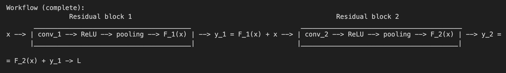

Workflow (simplified):  
x --> y_1 = F_1(x) + x --> y_2 = F_2(x) + y_1 --> L

- We're interested in $\frac{\partial L}{\partial x}$
- So due to backpropagation:

$\frac{\partial L}{\partial x} = \frac{\partial L}{\partial y_2} \cdot \frac{\partial y_2}{\partial y_1} \cdot \frac{\partial y_1}{\partial x}$

Compute derivatives:

- $\frac{\partial y_2}{\partial y_1} = F_2' + 1$
- $\frac{\partial y_1}{\partial x} = F_1' + 1$

So: $\frac{\partial L}{\partial x} = \frac{\partial L}{\partial y_2} \cdot (F_2' + 1) \cdot (F_1' + 1)$

> Expand it:  
> **$(F_2' + 1)(F_1' + 1) = F_2'F_1' + F_2' + F_1' + 1$**  
> **gradient = sum of 4 terms (4 paths)**

The paths:

1. F_2'F_1' → full deep path (bad)
2. F_2' → skip first block
3. F_1' → skip second block
4. 1 → skip BOTH blocks (pure identity)

We say “paths” because:

- *each term corresponds to a different route through the network
- mathematically they all appear in the sum

So:

> paths are NOT choices  
> paths are contributions

> Let's see if this helps with the vanishing gradient case:

Assume: $F_1' = F_2' = 0.1$

**Normal CNN**  
gradient = 0.1 × 0.1 = 0.01  
→ already small  
→ deeper → goes to 0

**ResNet**  
gradient = 0.1×0.1 + 0.1 + 0.1 + 1 = 0.01 + 0.1 + 0.1 + 1 = 1.21  
**gradient ≈ 1.21 → NOT vanishing**

> Let's see if this helps with the exploding gradient case:

Assume $F_1' = F_2' = 2$

**Normal CNN**  
gradient = 2 × 2 = 4  
→ deeper → explodes fast

**ResNet**  
gradient = 2×2 + 2 + 2 + 1 = 4 + 2 + 2 + 1 = 9  
**FUUUUCCKK, it's even higher, it explodes even more ....**

> ResNet does NOT magically stop explosion :)

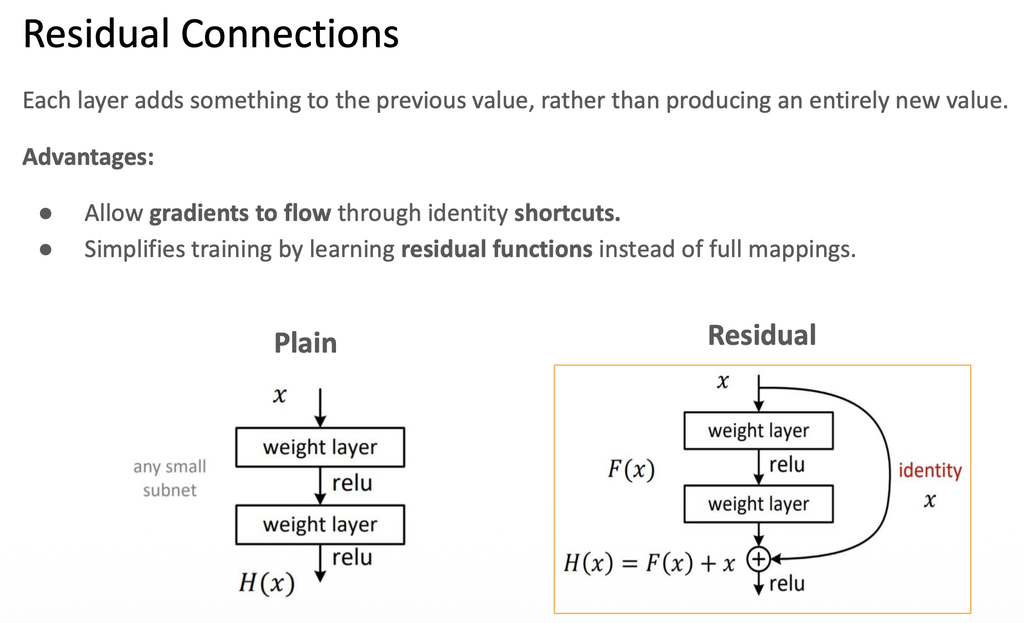

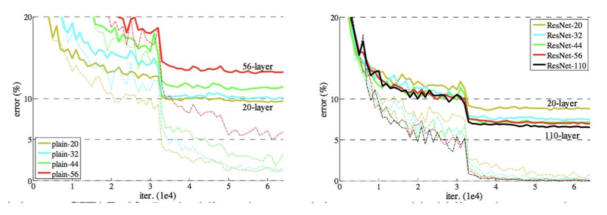

Plot shows:

- y-axis = error (%)
- x-axis = training iterations

> Left plot (NORMAL CNN)
- more layers → WORSE performance
- 20-layer → OK
- 56-layer → worse
- 44-layer → worse

> This is NOT overfitting

Even training error is worse.

> Right plot (ResNet)
- more layers → BETTER performance
- 20-layer → ok
- 56-layer → better
- 110-layer → EVEN better

> **ResNet unlocks depth**

**CONCLUSION**:

- problem was NOT model capacity
- problem was **training difficulty**
  - Capacity = how powerful the model is (what it COULD learn)
  - Training difficulty = how hard it is to actually FIND those weights
    - Deep CNN can represent a good solution (high capacity)
    - But SGD can’t find it (optimization is hard)
      - So the model is not weak
      - BUT training fails to reach good solution

#### Optimization

- deeper models are harder to optimize
  - we saw this, that's because of
    - vanishing gradients
    - exploding gradients
- deeper model should perform at least as well as shallow WE ARE REFERRING TO A **CNN**, in general
  - if you have
    - Model A: 10 layers
    - Model B: 50 layers
  - Model B could just COPY Model A
  - And make extra layers do: identity: output = input
  - SO deeper model should NEVER be worse
  - BUT IN REALITY: it IS worse (without ResNet)
  - Because network CANNOT learn identity easily

Normal CNN must learn:  
H(x) = x  
HARD

ResNet:  
y = F(x) + x  
F(x) = 0 --> y = x  
EASY

> **learning “do nothing” is easier than copying perfectly**

**What about all thr stuff we previously said about gradients?**

> Gradients are about HOW we reach F(x) = 0  
> NOT WHAT the layer outputs

We previously said: gradient = F2’F1’ + F2’ + F1’ + 1 --> how can gradient be 1? You absolute donkey: you're thinking if the layer outputs identity → gradient = 1 --> NO, the gradient have a value and that gradient (computed as we said as F2’F1’ + F2’ + F1’ + 1) allows the model to learn F(x) = 0 --> y = F(x) + x --> y = 0 + x --> y = x.

So for example in this residual layer:

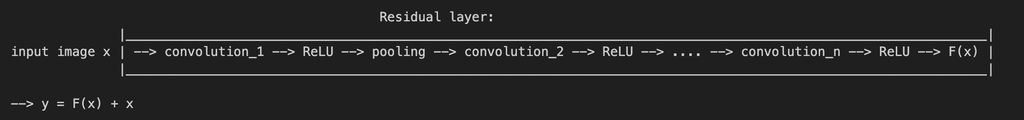

The model learns the parameters transform X into 0 --> F(x) = 0 --> y = x --> the whole residual block learns to behave like identity --> it's as if the input "skipped" that residual layer

# ResNet actual architecture

> ResNet = MANY residual blocks stacked together

#### Generic structure

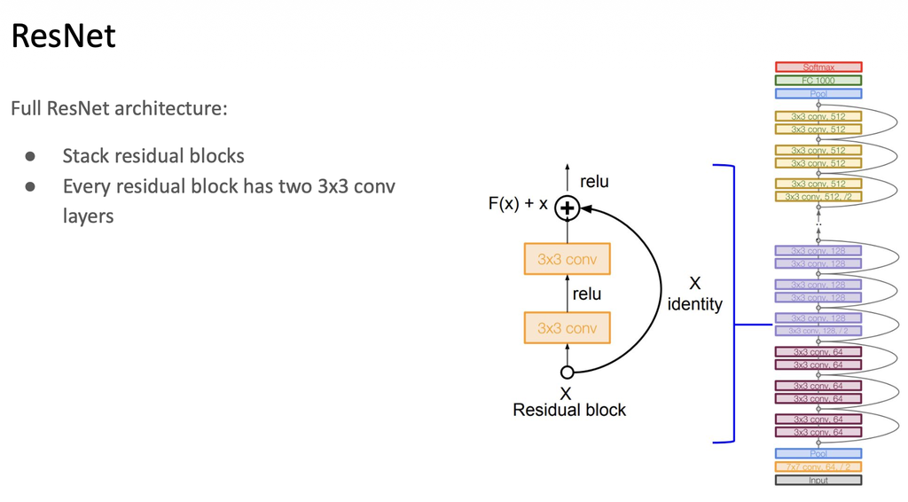

Input image  
↓  
Initial conv layer  
↓  
Pooling  
↓  
Residual blocks (many)  
↓  
Residual blocks (more, deeper, wider)  
↓  
Global average pooling  
↓  
Final classifier (FC)  
↓  
Softmax

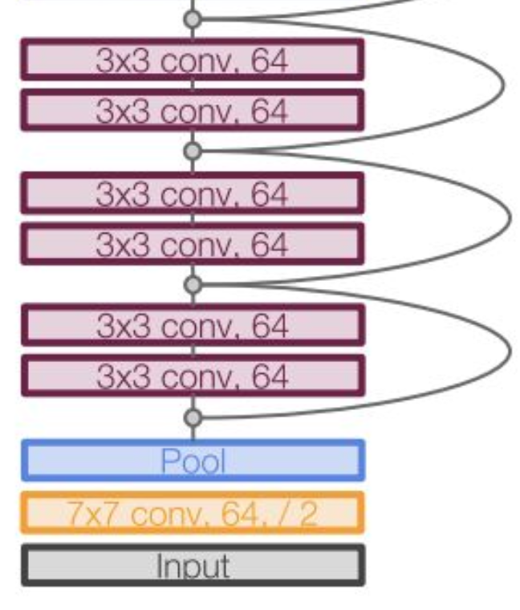

#### Beginning

Why convulation right now?

- Reduce resolution early → cheaper computation
- Extract low-level features

# First set of residual blocks

> Then we apply **3 residual layers**  
> **Each residual layer is composed by 2 convolutional layer**  
> They're all the same convulational layer: **64 channels as input, 64 filters (so 64 channels as output), kernel size 3x3, stride = 1, padding = 1**

#### WTF what sense does it make to apply the same convoloutional layer 6 times????

> They have the SAME STRUCTURE  
> BUT DIFFERENT WEIGHTS

So each layer is: 3x3 conv, 64 **BUT EACH BLOCK HAS ITS OWN WEIGHTS**

> Block 1 → W1  
> Block 2 → W2  
> Block 3 → W3

#### Why repeat same structure?

Because we want to progressively refine features  
We perform the same operation type, BUT with different parameters

#### How does the input shape change inside these 3 residual blocks?

$H_{out} = \frac{H_{in} - K + 2P}{S} + 1$

They all have:

- Kernel = 3
- Stride = 1
- Padding = 1

So:

- $H_{out} = \frac{H - 3 + 2(1)}{1} + 1 = \frac{H - 3 + 2}{1} + 1 = H$
- Same for width

So:

- output height = input height
- output width = input width

#### Why are we keeping the same size as the input?

> Remember that each residual block does: $y = F(x) + x$  
> For this to work F(x) and x MUST have same shape

#### Why stack 3 residual blocks?

Each block does a **small correction**  
So by stacking them: x → refine → refine → refine

What these e residual blocks are doing is: refine features without changing resolution

This is how residual blocks are usually implemented, you don't put a huge number of layers inside each residual blocks

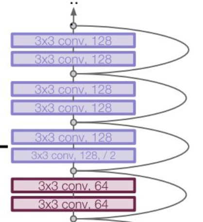

# Second set of residual blocks

#### Dimension check

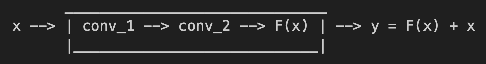

The input X has dimensions: (64, 56, 56)  
The first residual block output has dimension: $H_{out} = \frac{56 - 3 + 2}{2} + 1 = \frac{55}{2} + 1 = 27.5 + 1 = 28.5 → 28$ --> (128, 28, 28)  
**GODDAMN** --> we cannot compute $y = F(x) + x$ because of the dimension mismatch

#### Solution: projection shortcut

we transform x --> we pass the input X through a convoulational layer to match F(x) shape:

- Kernel = 1×1
- Stride = 2
- Output channels = 128

x: (64, 56, 56) → 1×1 conv → (128, 28, 28)  
Now instead of X we'll represent the modified x as: W_s x

So now we can perform: $y = F(x) + W_s x$

> So after the first block we have (128, 28, 28)

#### Rest of the residual blocks?

They're the same as the first one --> now no more shape changes as: 3×3 conv, stride 1, padding 1  
The output of these 3 residual blocks is: (128, 28, 28)

> we are reducing the resolution (number of pixels) and increase channels (more filter outputs, more feature maps)

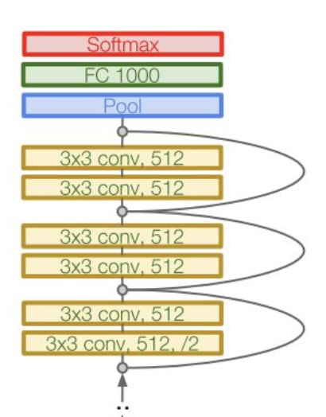

# Third set of residual blocks

Before entering in the 3 last residual blocks we have shape: (256, 14, 14) (the slides skip the 256 layers because they're fucking idiots)

#### Dimension check

$H_{out} = \frac{14 - 3 + 2}{2} + 1 = \frac{13}{2} + 1 = 6.5 + 1 = 7.5 → 7$ --> (512, 7, 7)

Same problem as before, we have:

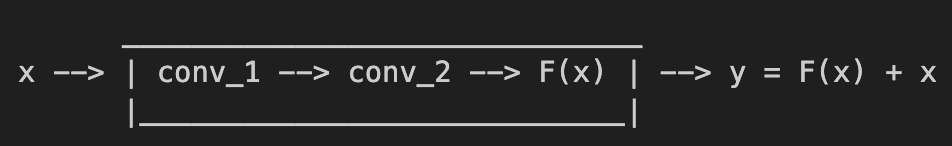

x : (256, 14, 14) F(x): (512, 7, 7)

We cannot sum them --> projection shortcut --> pass X thought a convolutional layer with:

- kernel: 1×1
- stride = 2
- channels = 512

Now: x → (512, 7, 7)  
So we can do: y = F(x) + W_s x

Last 2 residual blocks keep the now transformed input (512, 7, 7) as it is:

- 3×3 conv, 512, stride 1, padding 1
- 3×3 conv, 512, stride 1, padding 1

# Last part of the NN: pooling + FC + softmax

### Pooling

#### What kind of pooling are we using?

**Global Average Pooling**  
Forces to keep only one value for each channel:

- we have (512, 7, 7) --> 512 stacke matrixes, each matrix is a 7x7
- for each of the 512 7x7 matrix compute the average number --> from (512, 7, 7) to (512, 1, 1)
- so from each channel → we keep 1 number

> Now we can flatten the image --> 512 x 1 x 1 = 512

### FC

- Input: (512)

**Pass it through a fully connected layer that takes input with 512 dimensions --> maps them into outputs with 1000 dimensions**

- Output: (1000)

So each input is now associated with 1000 numbers --> 1 number for each class as ImageNet has 1000 classes --> **NOTE: THEY'RE NOT PROBABILITY YET, JUST LOGITS**  
Since fully connected layer do: $y = W x + b$ --> we need to add the bias to each output, so:  
$y = W x + b$

- $x ∈ \mathbb{R}^{512}$
- $W ∈ \mathbb{R}^{1000 × 512}$

#### Softmax

Finally we transform 1000 scores into 1000 probabilities

[figure not shown]